# Applications of Data Science

Datafied self - Adrian Lehrner

2023-04-10

# 1. Dataset after reading in csv file

This output shows a small part of the dataset. The different datasets of the sensors have been combined into one dataset and a new column “Activity” has been added.

Head of the Dataframe with 1 column for every sensor

| X_acc | X_hPa | X_rad | X_linacc | X_µT | Activity |
| --- | --- | --- | --- | --- | --- |
| -3.656746 | 993.4352 | 5.40708780 | -3.9807026 | -28.163292 | fahrrad |
| -1.297652 | 993.4512 | 0.19785871 | 0.4741257 | 6.101456 | fahrrad |
| -2.451302 | 993.4512 | -0.09114313 | -0.1024862 | 4.411934 | fahrrad |
| -6.856941 | 993.4512 | -0.69596463 | 2.1904757 | 3.494606 | fahrrad |
| -2.876269 | 993.4512 | 0.22384980 | -0.7286204 | -4.406799 | fahrrad |

On the plot below, the measurements for the acceleration are shown using a line plot. The different background colors show the different activities.

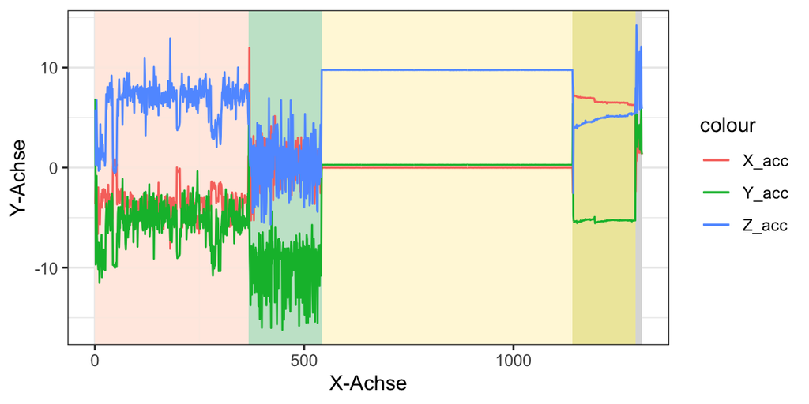

# 2. Differences in Delta T

By making use of the box plot, now it is explored how different values for delta t affect the data.

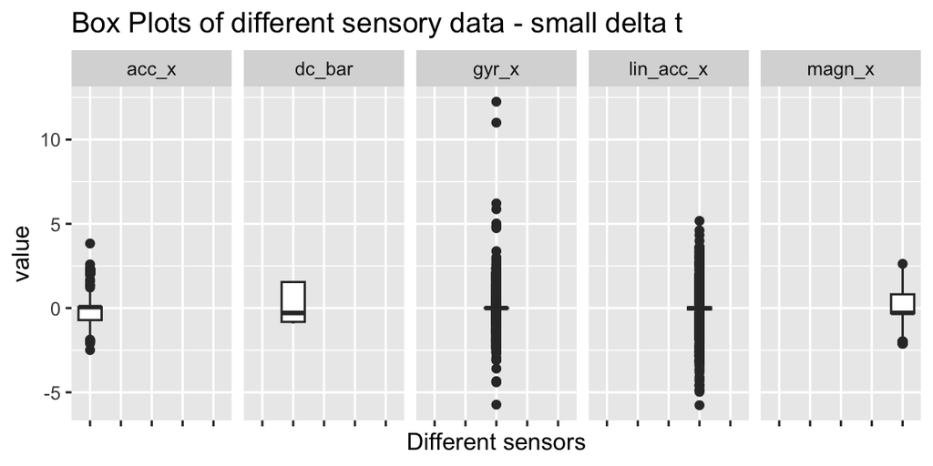

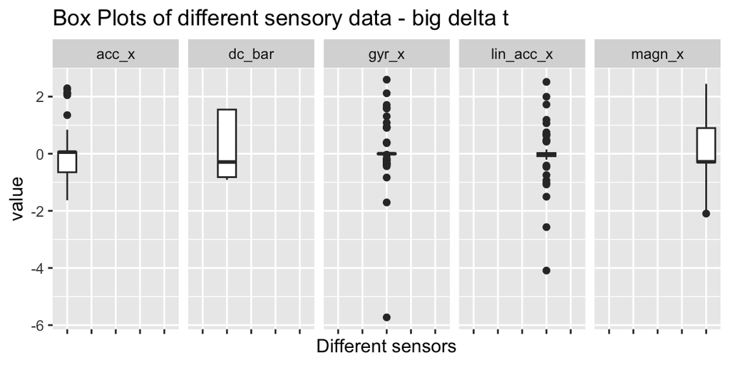

## 2.1 Interpretation of data

As we can see the smaller delta t, the more variation we also have in the data. This is due to measurement errors which add up if you collect data within smaller periods of time.

In general, when it comes to the pros and cons of delta t, a few of the following are worth mentioning:

### Pros:

1. Less data storage required: With a higher value of delta t, there will be fewer data points to store, which can save storage space and reduce the cost of data storage.
2. Less processing power required: With fewer data points to process, less processing power may be required for data analysis.
3. May be sufficient for certain applications: In some cases, a higher value of delta t may be sufficient for the needs of the application. For example, if the data is being used to monitor long-term trends, a lower time resolution may be adequate.

### Cons:

# 3. Outlier detection with dbscan

The purpose of using the kNNdistplot function is to determine a good value for the eps parameter in the dbscan clustering algorithm, which is used to cluster the data points. The eps parameter specifies the maximum distance between two points in the same cluster, and the MinPts parameter specifies the minimum number of points required to form a dense region in the cluster.

The kNNdistplot function generates a plot that shows the distribution of k-nearest neighbor distances. By visually inspecting the plot, one can identify a “knee” or elbow point in the curve where the rate of change of the distances becomes more gradual. This knee point can be used as a threshold to determine a good value for the eps parameter.

In the code, the knee point is estimated to be at a distance of 4.5, which is marked on the plot with a red line using the abline function. This value is then used as the eps parameter in the dbscan function to cluster the data points. Any points that do not belong to any cluster are considered outliers and are highlighted in red in the final plot.

The same method is applied to find outliers in all the other columns of the dataset (=different sensors).

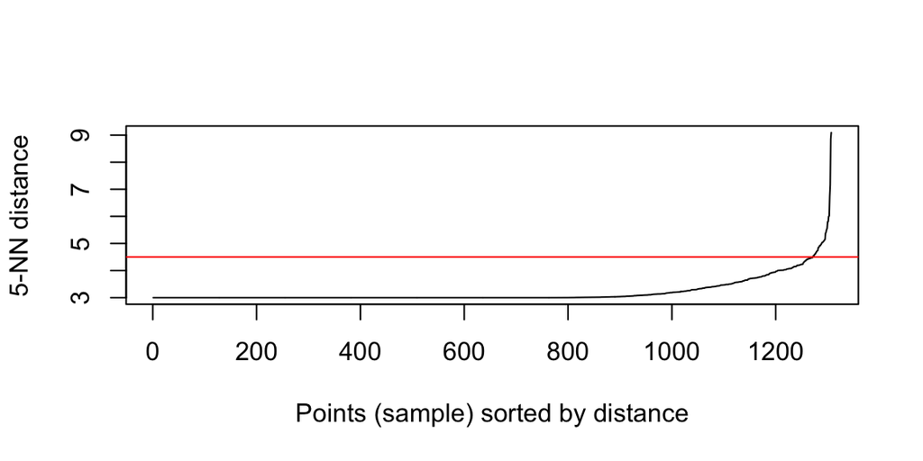

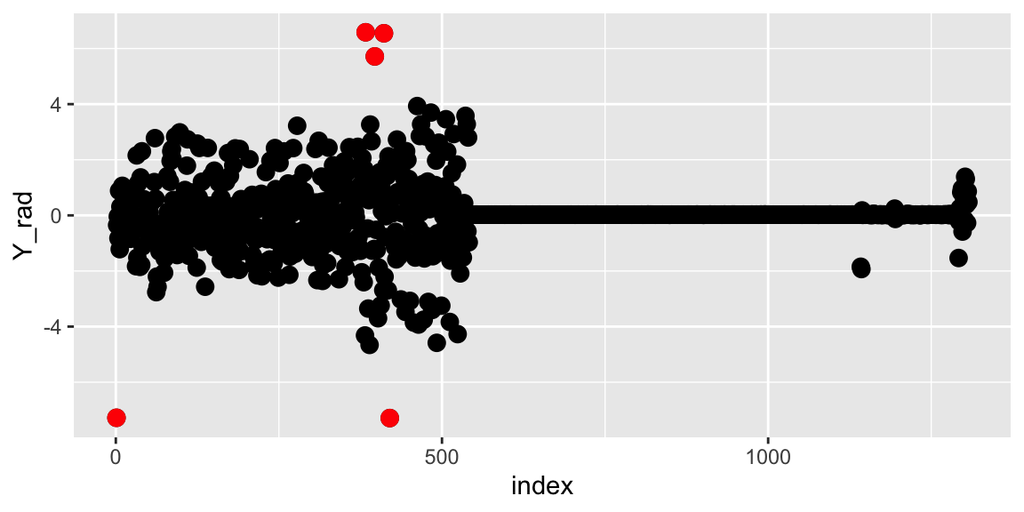

In total outliers have been detected in 27 different rows. Since this is only around 2% of the whole dataset the rows of the outliers will just be deleted.

# 4. Feature engineering - Temporal Aggregation of data

In the following example the approach of feature engineering in a time domain was chosen. For each column of the acceleration dimension the change was calculated. Then, the different changes were combined into one column (avg_change_Acc), after that the “rolling_sum” was calculated, which is the sum of the previous 10 entries. Since there are many different columns e.g., acceleration in 3 different dimensions, it might make sense to combine these different columns into one column summarizing the overall change that takes place. Besides other advantages, this might lead to less computing power needed to process all the data.

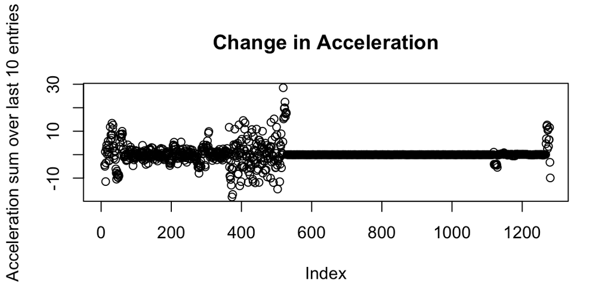

# 5. PCA to get a better understanding of the data

In order to get a better understanding of my data and see which variables contribute the most in conducted a PCA. I excluded several column (Activity type, index and time), since they would not be meaningful and only distort the outcome.

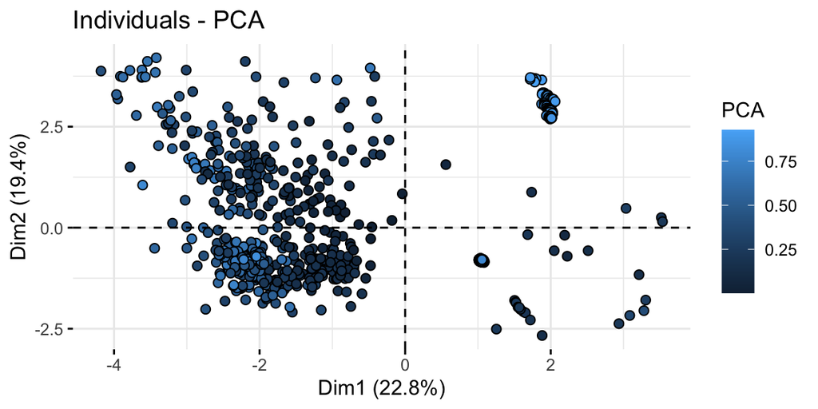

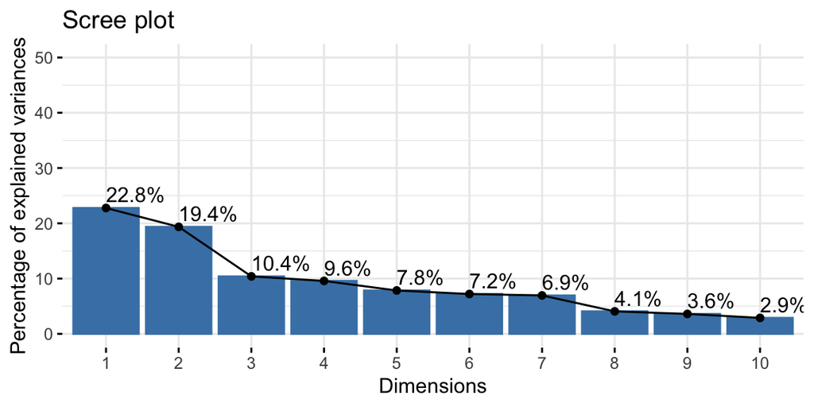

In the following graph it is depicted which variables contribute how much to the first principal component. As shown in the graphs the rolling sum column does not contribute a lot to explain the variance.

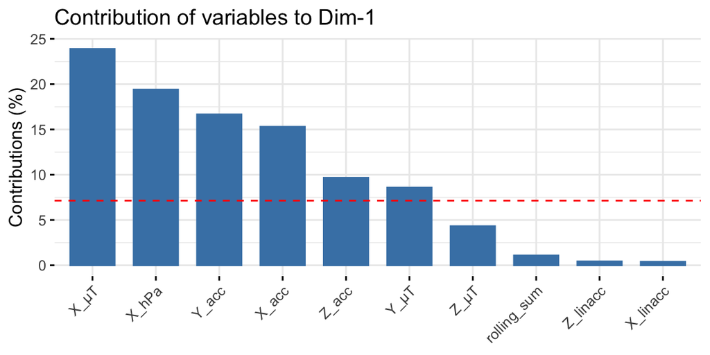

# 6. Clustering the Activity types

The graph below shows the sensory data graphically represented on the first to Principal Components. The ellipses around the data points show the real groups of activities.

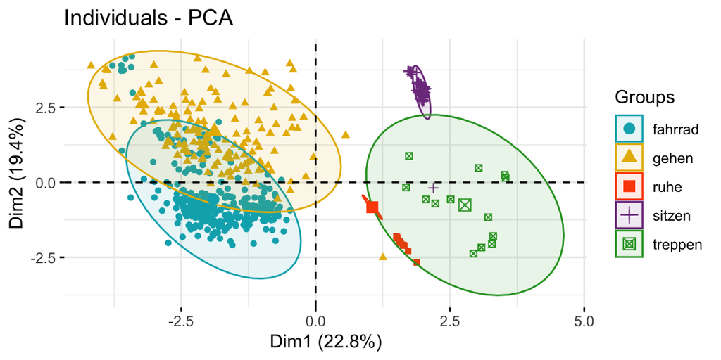

In the following section two different clustering methods (hierarchical clustering and k-means) have been tried out and will be compared to the “real clusters”.

## 6.1 Hierachical clustering

This graph shows the result of the hierarchical clustering using the scaled data.

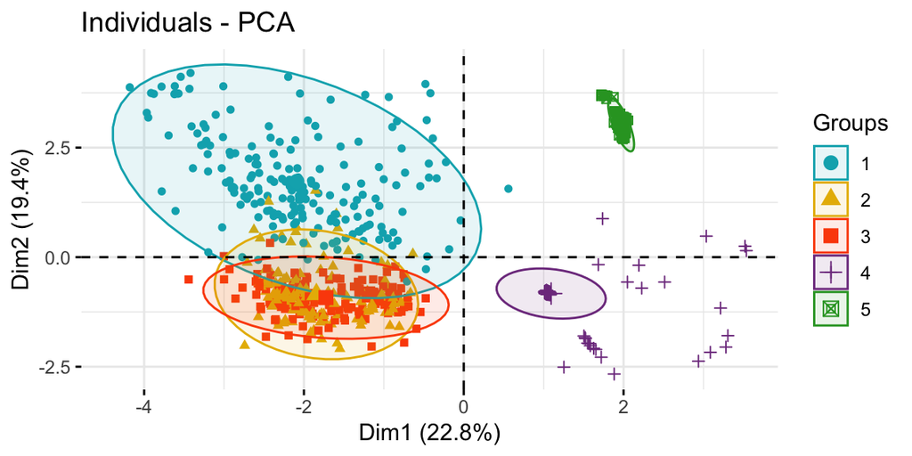

The graph also uses hierarchical clustering, but not using all the scaled data points, but just clustering based on the first two principal components. It can be argued that this clustering approach works slightly better.

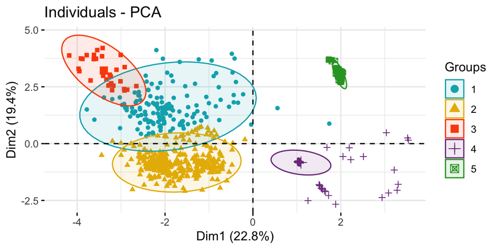

## 6.2 K-means clustering

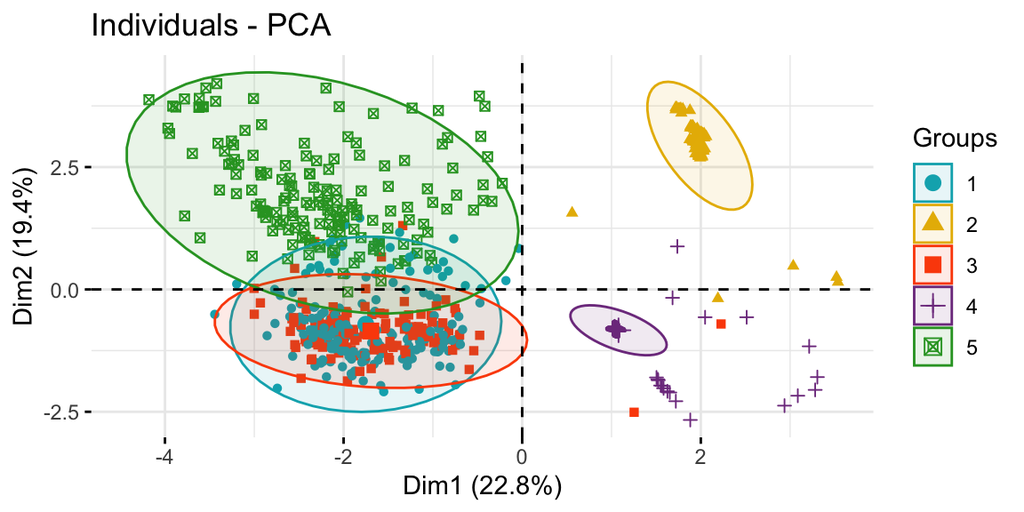

This last graph again is the result of the k-means clustering, however, not on all the data points, but just the first two principal components. It is similar to k-means with all the data points, but distinguishes the groups even more from each other.

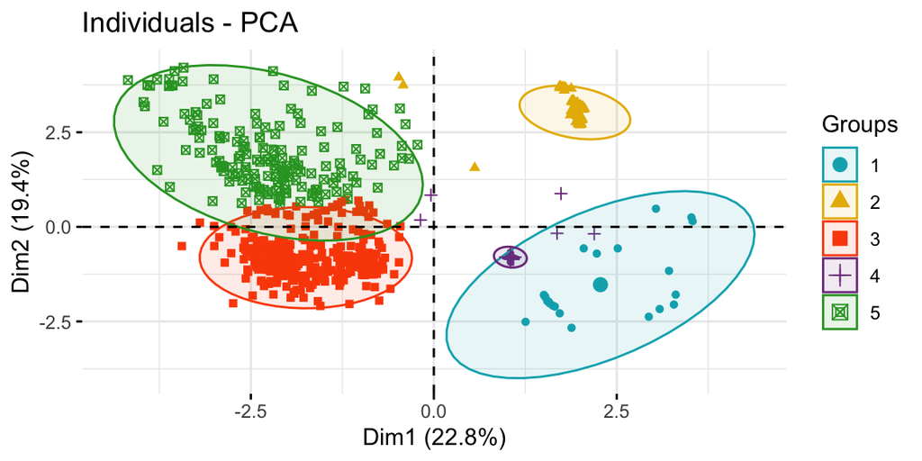

# 7. ML - Classification tree to classify Activities

Finally, a decision tree was tried out to see how well a model might work to predict activity based on future measurements.

# 7.1 Classification tree - original

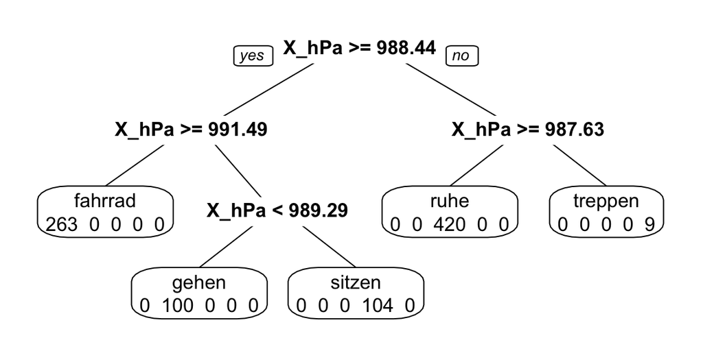

### Model evaluation

```
## Accuracy: 1
```

|  | fahrrad | gehen | ruhe | sitzen | treppen |
| --- | --- | --- | --- | --- | --- |
| fahrrad | 101 | 0 | 0 | 0 | 0 |
| gehen | 0 | 54 | 0 | 0 | 0 |
| ruhe | 0 | 0 | 180 | 0 | 0 |
| sitzen | 0 | 0 | 0 | 45 | 0 |
| treppen | 0 | 0 | 0 | 0 | 4 |

As depicted above, the decision tree only takes the variables from the barometer to make classifications. When looking at the data of the barometer this is not surprising.

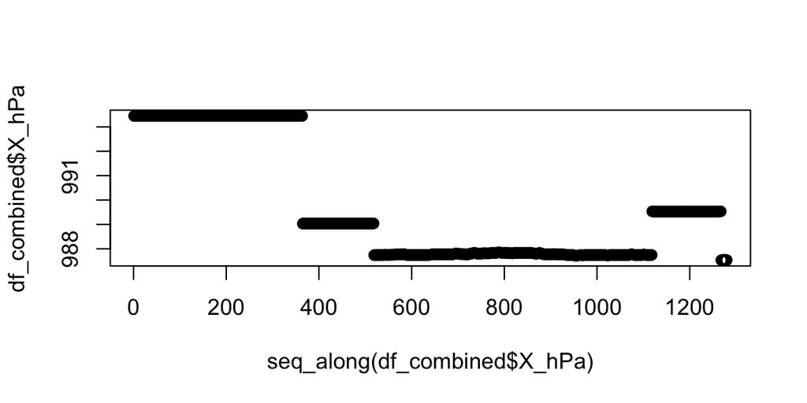

# 7.2 Classification tree - scaled

The same holds true for the scaled model.

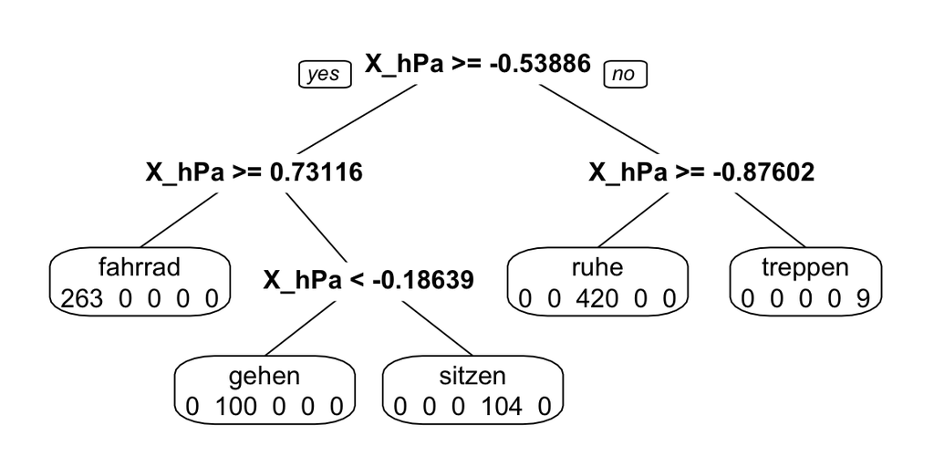

### Model evaluation

```
## Accuracy: 1
```

|  | fahrrad | gehen | ruhe | sitzen | treppen |
| --- | --- | --- | --- | --- | --- |
| fahrrad | 101 | 0 | 0 | 0 | 0 |
| gehen | 0 | 54 | 0 | 0 | 0 |
| ruhe | 0 | 0 | 180 | 0 | 0 |
| sitzen | 0 | 0 | 0 | 45 | 0 |
| treppen | 0 | 0 | 0 | 0 | 4 |